# Exercise 09

2024-03-18

### Step 1

- Using the {tidyverse} read_csv() function, load the “Street_et_al_2017.csv” dataset from this URL as a “tibble” named d.
- Do a quick exploratory data analysis where you generate the five-number summary (median, minimum and maximum and 1st and 3rd quartile values), plus mean and standard deviation, for each quantitative variable.

```r
# Set up libraries
library(tidyverse)
library(skimr)
library(tidyr)
library(broom)
library(infer)
```

```r
f <- "https://raw.githubusercontent.com/difiore/ada-2024-datasets/main/Street_et_al_2017.csv"
d <- read_csv(f, col_names = TRUE)
# Quick glance
head(d)
```

```
## # A tibble: 6 × 13
##   Species       Taxonomic_group Social_learning Research_effort   ECV Group_size
##   <chr>         <chr>                     <dbl>           <dbl> <dbl>      <dbl>
## 1 Allenopithec… Catarrhini                    0               6  58.0       40
## 2 Allocebus_tr… Catarrhini                    0               6  NA          1
## 3 Alouatta_bel… Platyrrhini                   0              15  52.8        7.4
## 4 Alouatta_car… Platyrrhini                   0              45  52.6        8.9
## 5 Alouatta_gua… Platyrrhini                   0              37  51.7        7.4
## 6 Alouatta_pal… Platyrrhini                   3              79  49.9       13.1
## # ℹ 7 more variables: Gestation <dbl>, Weaning <dbl>, Longevity <dbl>,
## #   Sex_maturity <dbl>, Body_mass <dbl>, Maternal_investment <dbl>,
## #   Repro_lifespan <dbl>
```

```r
# From {skimr}; provides n_missing, mean, sd, and five number summary (min, max, Q1, median, Q3)
skim(d)
```

Data summary

| Name | d |
| --- | --- |
| Number of rows | 301 |
| Number of columns | 13 |
| _______________________ |  |
| Column type frequency: |  |
| character | 2 |
| numeric | 11 |
| ________________________ |  |
| Group variables | None |

**Variable type: character**

| skim_variable | n_missing | complete_rate | min | max | empty | n_unique | whitespace |
| --- | --- | --- | --- | --- | --- | --- | --- |
| Species | 0 | 1 | 10 | 41 | 0 | 301 | 0 |
| Taxonomic_group | 0 | 1 | 10 | 12 | 0 | 3 | 0 |

**Variable type: numeric**

| skim_variable | n_missing | complete_rate | mean | sd | p0 | p25 | p50 | p75 | p100 | hist |
| --- | --- | --- | --- | --- | --- | --- | --- | --- | --- | --- |
| Social_learning | 98 | 0.67 | 2.30 | 16.51 | 0.00 | 0.00 | 0.00 | 0.00 | 214.00 | ▇▁▁▁▁ |
| Research_effort | 115 | 0.62 | 38.76 | 80.59 | 1.00 | 6.00 | 16.00 | 37.75 | 755.00 | ▇▁▁▁▁ |
| ECV | 117 | 0.61 | 68.49 | 82.84 | 1.63 | 11.82 | 58.55 | 86.20 | 491.27 | ▇▁▁▁▁ |
| Group_size | 114 | 0.62 | 13.26 | 15.20 | 1.00 | 3.12 | 7.50 | 18.23 | 91.20 | ▇▂▁▁▁ |
| Gestation | 161 | 0.47 | 164.50 | 38.00 | 59.99 | 138.35 | 166.03 | 183.26 | 274.78 | ▁▅▇▃▁ |
| Weaning | 185 | 0.39 | 311.09 | 253.08 | 40.00 | 121.66 | 234.16 | 388.78 | 1260.81 | ▇▃▁▁▁ |
| Longevity | 181 | 0.40 | 331.97 | 165.67 | 103.00 | 216.00 | 301.20 | 393.30 | 1470.00 | ▇▂▁▁▁ |
| Sex_maturity | 194 | 0.36 | 1480.23 | 999.23 | 283.18 | 701.52 | 1427.17 | 1894.11 | 5582.93 | ▇▆▂▁▁ |
| Body_mass | 63 | 0.79 | 6795.18 | 14229.83 | 31.23 | 739.44 | 3553.50 | 7465.00 | 130000.00 | ▇▁▁▁▁ |
| Maternal_investment | 197 | 0.35 | 478.64 | 292.07 | 99.99 | 255.88 | 401.35 | 592.22 | 1492.30 | ▇▅▂▁▁ |
| Repro_lifespan | 206 | 0.32 | 9064.97 | 4601.57 | 2512.16 | 6126.22 | 8325.89 | 10716.60 | 39129.57 | ▇▃▁▁▁ |

```r
# Make it a tibble
# (tibble_d <- skim(d)
#  tibble::as_tibble())

# You can also easily use group_by function to ...group...by... variables
# d %>%
#  dplyr::group_by(Species) %>%
#  skim()
```

### Step 2

- From this dataset, plot brain size (ECV) as a function of social group size (Group_size), longevity (Longevity), juvenile period length (Weaning), and reproductive lifespan (Repro_lifespan).

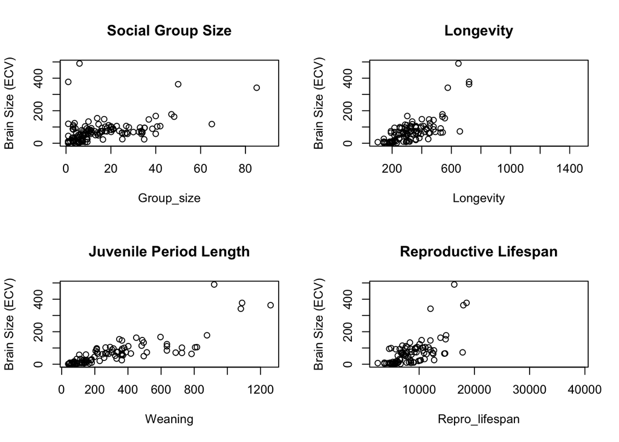

```r
par(mfrow = c(2, 2))
plot(data = d, ECV ~ Group_size, main = "Social Group Size", ylab = "Brain Size (ECV)")
plot(data = d, ECV ~ Longevity, main = "Longevity", ylab = "Brain Size (ECV)")
plot(data = d, ECV ~ Weaning, main = "Juvenile Period Length", ylab = "Brain Size (ECV)")
plot(data = d, ECV ~ Repro_lifespan, main = "Reproductive Lifespan", ylab = "Brain Size (ECV)")
```

### Step 3

- Derive by hand the ordinary least squares regression coefficients $\beta1$ and $\beta0$ for ECV as a function of social group size

```r
# I do not understand why this yields diff results; B1 = 2.718; B0 = -172.906
# Solve for Beta1, slope, by hand
# (B1 <- cor(d$ECV, d$Group_size, use = "complete.obs") * (sd(d$ECV, na.rm = TRUE)/sd(d$Group_size, na.rm = TRUE)))

# Solve for Beta0, intercept, by hand
# (B0 <- mean(d$ECV, na.rm = TRUE) - B1*mean(d$Group_size, na.rm = TRUE))

# Removing rows in ECV and Group_size that are not complete
ECV_GS_noNA <- d[complete.cases(d[ , c('ECV', 'Group_size')]), ]

# Rename the variables
ECV <- ECV_GS_noNA$ECV
Group_size <- ECV_GS_noNA$Group_size

# Solve for Beta1 (slope) by hand
(beta1 <- cor(ECV, Group_size) * (sd(ECV)/sd(Group_size)))
```

```
## [1] 2.463071
```

```r
# Solve for Beta0 (intercept) by hand
(beta0 <- mean(ECV) - beta1 * mean(Group_size))
```

```
## [1] 30.35652
```

### Step 4

- Confirm that you get the same results using the lm() function

```r
(ECV_GS_lm <- lm(ECV ~ Group_size, data = d))
```

```
##
## Call:
## lm(formula = ECV ~ Group_size, data = d)
##
## Coefficients:
## (Intercept)   Group_size
##      30.357        2.463
```

### Step 5

- Repeat the analysis above for three different major radiations of primates - “catarrhines”, “platyrrhines”, and “strepsirhines”) separately. These are stored in the variable Taxonomic_group. Do your regression coefficients differ among groups? How might you determine this?
- The intercepts (B0) vary between the groups, but the slopes (B1) are more similar.

```r
cat <- filter(ECV_GS_noNA, Taxonomic_group == "Catarrhini")
cat_lm <- lm(ECV ~ Group_size, data = cat)
plat <- filter(ECV_GS_noNA, Taxonomic_group == "Platyrrhini")
plat_lm <- lm(ECV ~ Group_size, data = plat)
strep <- filter(ECV_GS_noNA, Taxonomic_group == "Strepsirhini")
strep_lm <- lm(ECV ~ Group_size, data = strep)

# Combine results into a single data frame
# from {tidyr} and {broom}
cat_lm <- tidy(cat_lm) %>%
  mutate(Primate = "Catarrhini")
plat_lm <- tidy(plat_lm) %>%
  mutate(Primate = "Platyrrhini")
strep_lm <- tidy (strep_lm) %>%
  mutate(Primate = "Strepsirhini")
(primate_lm <- bind_rows(cat_lm, plat_lm, strep_lm, .id = "Model"))
```

```
## # A tibble: 6 × 7
##   Model term        estimate std.error statistic     p.value Primate
##   <chr> <chr>          <dbl>     <dbl>     <dbl>       <dbl> <chr>
## 1 1     (Intercept)    83.4     14.9        5.59 0.000000438 Catarrhini
## 2 1     Group_size      1.15     0.579      1.98 0.0518      Catarrhini
## 3 2     (Intercept)    16.2      7.39       2.19 0.0356      Platyrrhini
## 4 2     Group_size      1.97     0.455      4.32 0.000136    Platyrrhini
## 5 3     (Intercept)     8.18     2.14       3.83 0.000404    Strepsirhini
## 6 3     Group_size      1.84     0.473      3.89 0.000332    Strepsirhini
```

### Step 6

- For your first regression of ECV on social group size, calculate the standard error for the slope coefficient, the 95% CI, and the p value associated with this coefficient by hand. Also extract this same information from the results of running the lm() function.

```r
# Summary from Step 4
summary <- tidy(ECV_GS_lm)

# standard error of slope coefficint B1 = sqrt(MSE/SSX)
# MSE = SSE / df_error
# SSE = sum(residuals)^2
# SSX = sum((x - mean)^2)

SSE <- sum(ECV_GS_lm$residuals^2)
df_error <- nrow(ECV_GS_noNA) - 1 - 1
MSE <- SSE/df_error
SSX <- sum((ECV_GS_lm$model$Group_size - mean(ECV_GS_lm$model$Group_size))^2) # x variation
B1_SE <- sqrt(MSE/SSX)
B1_SE # standard error for the slope coefficient
```

```
## [1] 0.3508061
```

```r
# 95% confidence interval
alpha <- 0.05
lower <- summary$estimate - qt(1 - alpha/2, df = nrow(ECV_GS_noNA) - 2) *summary$std.error
upper <- summary$estimate + qt(1 - alpha/2, df = nrow(ECV_GS_noNA) - 2) *summary$std.error
CI <- cbind(lower, upper)
rownames(CI) <- c("(Intercept)", "Group size")
colnames(CI) <- c(paste0(as.character(alpha/2 * 100), " %"), paste0(as.character((1 -
    alpha/2) * 100), " %"))
CI
```

```
##                 2.5 %    97.5 %
## (Intercept) 16.926896 43.786153
## Group size   1.769874  3.156269
```

```r
# p value
summary$calc.statistic <- (summary$estimate-0)/summary$std.error
#(p <- pt(z, df = n - 1, lower.tail = FALSE))
summary$calc.p.value <- 2 * pt(summary$calc.statistic, df = nrow(ECV_GS_noNA) - 2, lower.tail = FALSE)

# print summary
summary
```

```
## # A tibble: 2 × 7
##   term        estimate std.error statistic  p.value calc.statistic calc.p.value
##   <chr>          <dbl>     <dbl>     <dbl>    <dbl>          <dbl>        <dbl>
## 1 (Intercept)    30.4      6.80       4.47 1.56e- 5           4.47     1.56e- 5
## 2 Group_size      2.46     0.351      7.02 7.26e-11           7.02     7.26e-11
```

```r
# Using lm() function completed in step 4
summary(ECV_GS_lm)
```

```
##
## Call:
## lm(formula = ECV ~ Group_size, data = d)
##
## Residuals:
##    Min     1Q Median     3Q    Max
## -92.05 -29.25 -15.14  13.07 445.28
##
## Coefficients:
##             Estimate Std. Error t value Pr(>|t|)
## (Intercept)  30.3565     6.7963   4.467 1.56e-05 ***
## Group_size    2.4631     0.3508   7.021 7.26e-11 ***
## ---
## Signif. codes:  0 '***' 0.001 '**' 0.01 '*' 0.05 '.' 0.1 ' ' 1
##
## Residual standard error: 60.31 on 149 degrees of freedom
##   (150 observations deleted due to missingness)
## Multiple R-squared:  0.2486, Adjusted R-squared:  0.2436
## F-statistic:  49.3 on 1 and 149 DF,  p-value: 7.259e-11
```

```r
glance(ECV_GS_lm)
```

```
## # A tibble: 1 × 12
##   r.squared adj.r.squared sigma statistic  p.value    df logLik   AIC   BIC
##       <dbl>         <dbl> <dbl>     <dbl>    <dbl> <dbl>  <dbl> <dbl> <dbl>
## 1     0.249         0.244  60.3      49.3 7.26e-11     1  -832. 1671. 1680.
## # ℹ 3 more variables: deviance <dbl>, df.residual <int>, nobs <int>
```